# STSCI 5065 - Lecture 12

Introduction to Apache Hive - Part 5: A Case Study Using Hive - Baseball Data Analysis

Harry Lu

# 1 Some Baseball Data

We have two data files, **`Batting.csv`** (95195 lines of text) and **`Master.csv`** (17916 lines of text)

# 2 Analysis Goals

- Find the player (ID only) with the highest runs for each year
- What are the First and last names of the player who had the highest runs in each year? Display the names, year and the highest runs
- Who (First name and last name) and in what year had the highest runs of all the years in the dataset?
- What is the run average of each year?
- What is the run average of all the years in the dataset?

# 3 Create a Temp Table and Load Data Form the Dataset

- In Ambari Hive View, create a table, `temp_batting`, to hold the data:

```
CREATE TABLE temp_batting (col_value STRING);
```

- Load the data file **`Batting.csv`** into `temp_batting`:

```
LOAD DATA INPATH "/mydata/lahman591-csv/Batting.csv"
OVERWRITE INTO TABLE temp_batting;
```

- Use Hive View to display some table contents (first 10 rows)

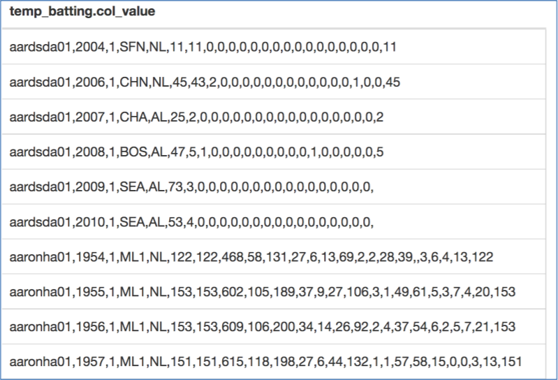

# 4 Create a Hive Table and Load Data Form a Query

- Extract the data: create a Hive table called `batting` to hold `player_id`, year and the number of runs:

```
CREATE TABLE batting (player_id STRING, year INT, runs INT);
```

- Insert data extracted from `temp_batting` with three regular expression (`regexp_extract`) calls:

```
INSERT OVERWRITE TABLE batting
SELECT
  regexp_extract(col_value, '^(?:([^,]*)\,?){1}', 1) player_id,
  regexp_extract(col_value, '^(?:([^,]*)\,?){2}', 1) year,
  regexp_extract(col_value, '^(?:([^,]*)\,?){9}', 1) runs
FROM temp_batting;
```

# 5 Display the Contents of the `batting` table in Hive View

```
batting.player_id  batting.year  batting.runs
---------------------------------------------
aardsda01          2004          0
aardsda01          2006          0
aardsda01          2007          0
aardsda01          2008          0
aardsda01          2009          0
aardsda01          2010          0
aaronha01          1954          58
aaronha01          1955          105
aaronha01          1956          106
aaronha01          1957          118
aaronha01          1958          109
aaronha01          1959          116
aaronha01          1960          102
aaronha01          1961          115
```

# 6 Query the Hive Table to Find the Yearly Max Runs

- Group the data by year to find the highest run score for each year

```
SELECT year, max(runs) max_run
FROM batting
GROUP BY year;
```

```
year  max_run
-------------
1871  66
1872  94
1873  125
1874  91
1875  115
1876  126
1877  68
1878  60
1879  85
1880  91
1881  86
1882  99
1883  110
1884  160
```

# 7 Query the Hive Table Using a `JOIN` Operation

- Get the `player_id`(s) to know who the player(s) was, using a `JOIN` operation on the condition of matching each year’s max number of runs:

```
SELECT a.year, a.player_id, a.runs
from batting a
JOIN
(SELECT year, max(runs) max_run
FROM batting
GROUP BY year) b
ON (a.year = b.year AND a.runs = b.max_run);
```

# 8 The `JOIN` Result

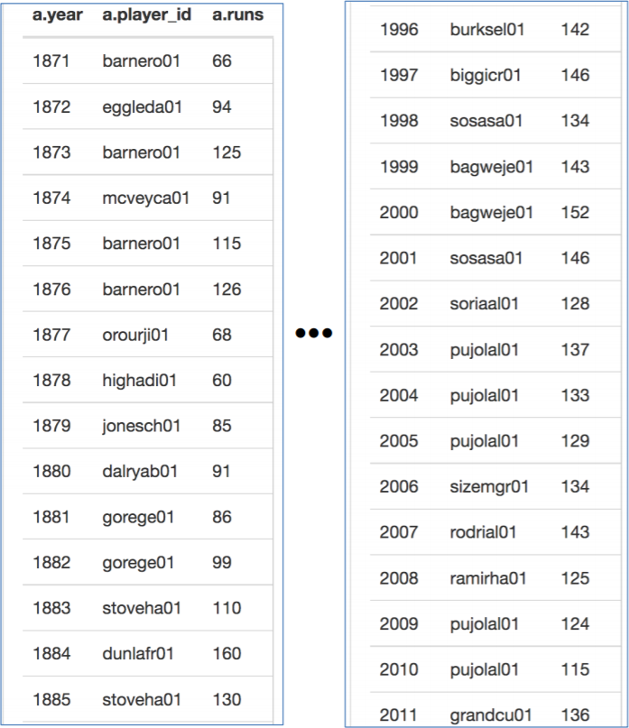

# 9 Create Another Table `master_data` Using Ambrari

[figure not shown]

# 10 Create a Hive View

```
CREATE VIEW year_max_runs as
  SELECT a.year, a.player_id, a.runs
  FROM batting a
  JOIN
  (SELECT year, max(runs) max_run
  FROM batting
  GROUP BY year) b
  ON (a.year = b.year AND a.runs = b.max_run);
```

# 11 Query: Who Had Highest Runs in Each Year

```
SELECT namefirst, namelast, m.playerid,
  year, runs max_runs
FROM year_max_runs y, master_data m
WHERE y.player_id = m.playerid;
```

# 12 Query Result

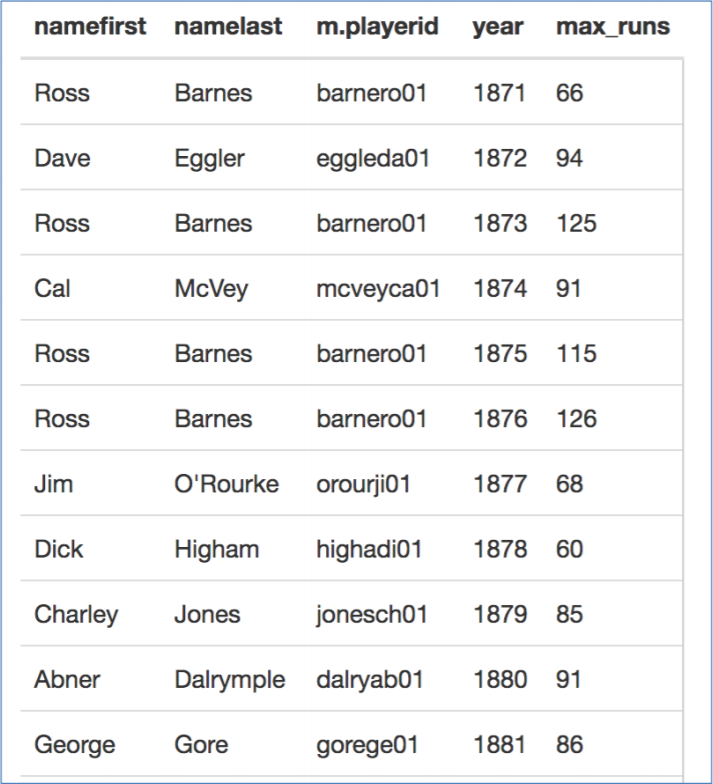

# 13 Find the Highest Runs of All the Years

```
SELECT namefirst, namelast, m.playerid,
  year, runs max_runs
FROM (SELECT max(runs) r FROM batting) y,
  master_data m, batting b
WHERE b.player_id = m.playerid
  AND y.r=b.runs;
```

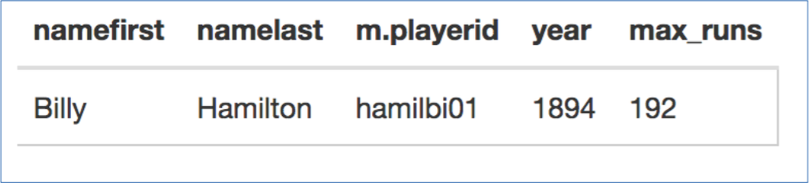

# 14 Find the Average Runs of Each Year

```
year  mean_runs
---------------
1871  23.12
1872  21.73
1873  28.64
1874  28.21
1875  19.42
1876  24.73
1877  21.03
1878  23.8
1879  26.84
....  .....
```

# 15 Find the Average Runs of All the Players in All the Years

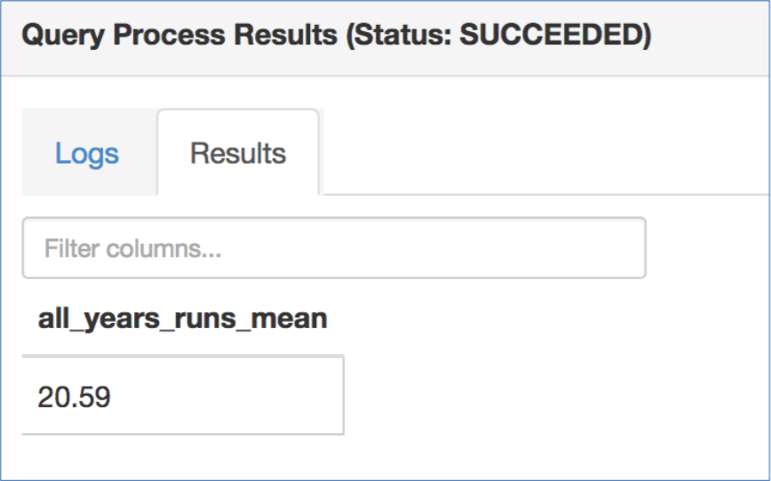

# 16 Using Regular Expression in Hive

| Regular Expression | Description |
| --- | --- |
| `^` | Beginning of string |
| `?: ()` | Grouping the value to return |
| `( [^,]*)` | Capture chars for buffer 1: a string of many noncomma chars (getting all the charts before you hit a comma) |
| `\,?` | Zero or one instance of comma character |
| `{1}` | Repeat group exactly 1 (or N) times |